# Linear Regression

## Classical Regression in the Time Series Context

Let assume a dependent time series, say, $X_t$, for $t=1,\cdots,n$, is being inﬂuenced by a collection of possible inputs or independent series, say, $Z_t^{(1)}, Z_t^{(2)}, \cdots, Z_t^{(q)}$. This assumption, necessary for applying conventional linear regression. We express this relation through the linear regression model

$$ X_t = \beta_0 + \beta_1 Z_t^{(1)} + \cdots + \beta_q Z_t^{(q)} + W_t $$

or expressed in vector form

$$ X_t = \boldsymbol{\beta}^T \boldsymbol{Z}_t+W_t $$

where $\boldsymbol{\beta}=[\beta_0, \cdots, \beta_q]^T$ and $\boldsymbol{Z}=[1, Z_t^{(1)}, \cdots, Z_t^{(q)}]^T$.

After the optimization (Ordinary Least Squares), we can get the optimal weights $\boldsymbol{\beta}$ defined as

$$ \hat{\boldsymbol{\beta}} = (Z^T Z)^{-1}Z^T \boldsymbol{X} $$

where $Z = [\boldsymbol{Z}_1 | \cdots | \boldsymbol{Z}_N]^T$ and $\boldsymbol{X}=(X_1, \cdots, X_N)^T$. This solution exists when the matrix $Z^T Z$ is nonsingular.

### Estimating Trends

Using a classical linear regression we can estimate the trend as a function of the time, where the time is the independent variable

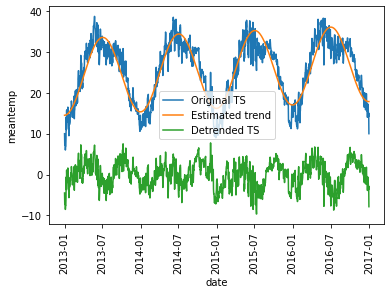

```python
ax.figure
```

After we found the optimal weights of the regression, $\hat{\boldsymbol{\beta}}$, we can compute the minimized error sum of squares, denoted as SSE, as

$$ SSE=\sum_{t=1}^N (X_t-\hat{\boldsymbol{\beta}}^T \boldsymbol{Z}_t)^2 $$

and an unbiased estimator for the variance $\sigma_W^2$, is

$$ s_W^2=MSE=\frac{SSE}{N-(q+1)} $$

where MSE denotes the mean squared error.

```
The SSE of trend estimator is 13951.021135820578
The MSE of trend estimator is 9.568601602071727
The standard deviation of trend estimator is 3.093315632468133
```

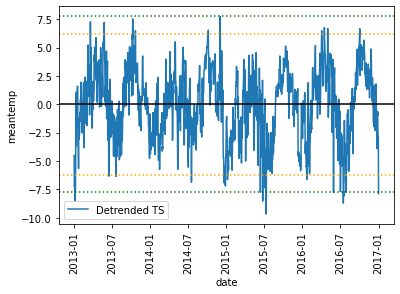

```python
print(f"The SSE of trend estimator is {sse}")
print(f"The MSE of trend estimator is {mse}")
print(f"The standard deviation of trend estimator is {mse_std}")

ax.figure
```

## Analysis of Variance (ANOVA)

Various competing models are of interest to isolate or select the best subset of independent variables. Suppose a proposed model specifies that only a subset $r<q$ intependent variables, say, $\boldsymbol{Z}_{t:r}=(Z_t^{(1)}, \cdots, Z_t^{(r)})^T$ is influencing the dependant variable $X_T$. The reduced model is

$$ X=Z_r \beta_r + W $$

where $\beta_r=(\beta_0, \beta_1, \cdots, \beta_r)^T$ is a subset of coefficients of the original $q$ variables and $Z_r = [ Z_{1:r}| \cdots| Z_{N:r} ]$ is the $N \times r$ matrix of inputs. The null hypotesis in this case is $H_0:\beta_{r+1}=\cdots=\beta_q=0$

We can test the reduced model against the full model by comparing the SSEs under two model using the F-statistics

$$ F = \frac{(SSE_r-SSE) / (q-r)}{SSE/(N-q-1)} = \frac{\text{Mean Squared Regression } (MSR)}{MSE} $$

Under the null hypothesis, $F$ has a central $F$-distribution with $q−r$ and $N-q-1$ degrees of freedom when $X=Z_r \beta_r + W$ is the correct model.

The null hypothesis is rejected at level $\alpha$ if $F > F_{N-q-1}^{q-r} (\alpha)$, the $1 − \alpha$ percentile of the F distribution with $q-r$ numerator and $N-q-1$ denominator degrees of freedom.

In simple words:

- The $F$-distribution set the probability of my null hypothesis to be incorrect (rejected).

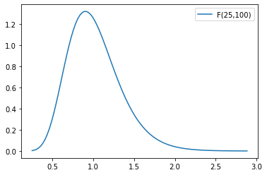

```python
ax.figure
```

The information involved in the test procedure is often summarized in an Analysis of Variance (ANOVA) table given by

| Source of Variation | Degrees of Freedom | Sum of Squares of Deviation | Mean Square | F | Pr(>F) |
| --- | --- | --- | --- | --- | --- |
| $$Z_t^{(r+1)}, \cdots, Z_t^{(q)}$$ | $$q-r$$ | $$SSR=SSE_r - SSE$$ | $$MSR=SSR/(q-r)$$ | $$F=MSR/MSE$$ | p-value |
| Error | $$n-(q+1)$$ | $$SSE$$ | $$MSE=SSE/(n-q-1)$$ |  |  |

### Example of ANOVA

```python
anova(
    data_trend,
    time_series,
    vars_names=np.array(["bias", "times", "cos_times"]),
    masks=np.array([[1, 1, 0], [1, 0, 1]])
)
```

|  | Source | Degrees of Freedom | Sum of Squares | Mean Square | F | Pr(>F) |
| --- | --- | --- | --- | --- | --- | --- |
| 0 | cos_times | 1 | 63592.606373 | 63592.606373 | 6645.96657 | 0.0 |
| 1 | times | 1 | 1373.570296 | 1373.570296 | 143.549742 | 0.0 |
| 2 | Error | 1458 | 13951.021136 | 9.568602 |  |  |

## $R^2$ metric

A special case of interest is the null hypotesis $H_0:\beta_1 = \cdots = \beta_q = 0$. In this case $r=0$ and the model becomes $X_t=\beta_0 + W_t$. We may measure the proportion of variation accounted for by all the variables using

$$ R^2 = \frac{SSE_0-SSE}{SSE_0} $$

where the residuals sum of squares under the reduced model is

$$ SSE_0 = \sum_{t=1}^{N} (X_t - \bar{X})^2 $$

The measure $R^2$ is called the *coefficient of determination*.

An alternative to previous techniques is to focus on a procedure for model selection that simply evaluates each model on its own merits. Suppose we consider a normal regression model with $k$ coefficients and denote the *maximum likelihood estimator* for the variance as

$$ \hat{\sigma}^2_k = \frac{SSE(k)}{N} $$

Then we have the next criterions for model selection

## Akaike's Information Criterion (AIC)

$$ AIC = log(\hat{\sigma}^2_k) + \frac{N+2k}{N} $$

The value of $k$ yielding the minimum AIC specifies the best model.

## AIC, Bias Corrected (AICc)

$$ AICc = log(\hat{\sigma}^2_k) + \frac{N+k}{N-k-2} $$

## Bayesian Information Criterion (BIC)

$$ BIC = log(\hat{\sigma}^2_k) + \frac{k log(N)}{N} $$

BIC is also called the Schwarz Information Criterion (SIC).

Notice that the penalty term in BIC is much larger than in AIC,consequently, BIC tends to choose smaller models. Various simulation studies have tended to verify that BIC does well at getting the correct order in large samples, whereas AICc tends to be superior in smaller samples where the relative number of parameters is large.

### Example of Criterions

```python
model_criterions(
    data_trend,
    time_series,
    vars_names=np.array(["bias", "times", "cos_times"]),
    masks=np.array([[1, 1, 1], [1, 1, 0], [1, 0, 1]])
)
```

|  | Model | k | SSE | df | MSE | R2 | AIC | AICc | BIC |
| --- | --- | --- | --- | --- | --- | --- | --- | --- | --- |
| 0 | bias,times,cos_times | 3 | 13951.021136 | 1459 | 9.562043 | 0.831792 | 3.259851 | 3.261238 | 2.270701 |
| 1 | bias,times | 2 | 77543.627509 | 1460 | 53.112074 | 0.064704 | 4.973771 | 4.975151 | 3.981005 |
| 2 | bias,cos_times | 2 | 15324.591431 | 1460 | 10.496296 | 0.805738 | 3.352389 | 3.353769 | 2.359623 |